# IODS course project

## Creating diagnostic plots and examining model assumptions

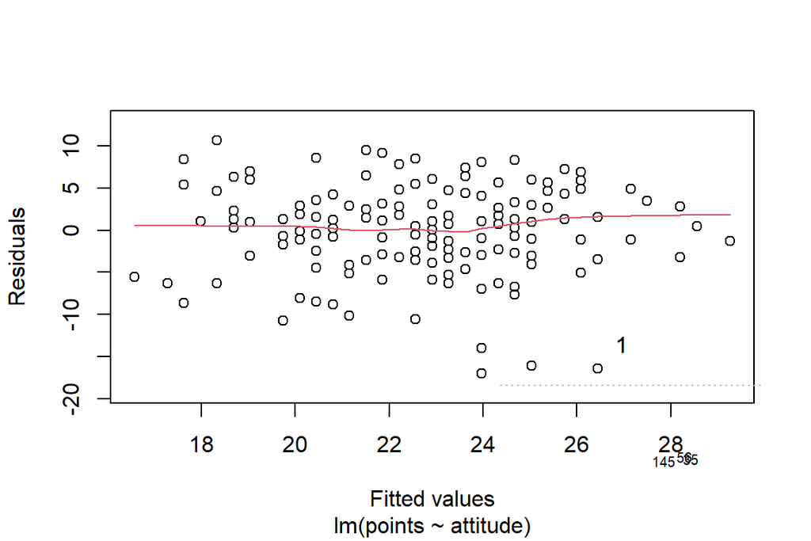

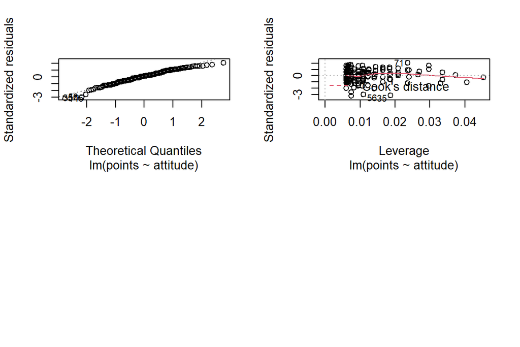

```r
#Plots for residuals vs fitted values (1), normal QQ-plot (2), and residuals vs. leverage (5)
plot(r1_model,which= c(1,2,5),
     par(mfrow = c(2,2)))
```

**A linear regression model has (among other things) the following assumptions in order to guarantee its predictions validity/reliability:**

- The error terms (i.e., residuals) of the model are normally distributed
- The residuals have constant variance on all x-variable values
- The data does not contain troublesome outliers
- There is a linear relationship between the y-variable and x-variables

**From the plots we see that:**

- the normality of errors is probably acceptable although some breakage from normality does exist on both ends (QQ-plot)
- The residuals seem to have a constant variance (the plot of residuals vs. fitted values)
- A couple observations have leverage of > 0.04. The model is probably acceptable without removing any of these observations

# Logistic regression analysis (week3)

```r
#loading libraries
library(tibble)
library(dplyr)
library(tidyr)
library(tidyverse)
library(ggplot2)
library(GGally)
library(plotly)
library(foreign)
library(tibble)
library(foreign)
library(corrgram)
library(psych)
```

## 1. General information

```r
#Reading in the joined (student alcohol consumption) data from online (due to the comment in the discussion forum about the correct Ns - I had too many....Although this seems to be the case also in the online link, oh well.)

alc <-read.table("http://s3.amazonaws.com/assets.datacamp.com/production/course_2218/datasets/alc.txt", sep=",", header=TRUE)

glimpse(alc) #382 participants, 35 variables.
```

```
## Rows: 382
## Columns: 35
## $ school     <chr> "GP", "GP", "GP", "GP", "GP", "GP", "GP", "GP", "GP", "G...
## $ sex        <chr> "F", "F", "F", "F", "F", "M", "M", "F", "M", "M", "F", "...
## $ age        <int> 18, 17, 15, 15, 16, 16, 16, 17, 15, 15, 15, 15, 15, 15, ...
## $ address    <chr> "U", "U", "U", "U", "U", "U", "U", "U", "U", "U", "U", "...
## $ famsize    <chr> "GT3", "GT3", "LE3", "GT3", "GT3", "LE3", "LE3", "GT3", ...
## $ Pstatus    <chr> "A", "T", "T", "T", "T", "T", "T", "A", "A", "T", "T", "...
## $ Medu       <int> 4, 1, 1, 4, 3, 4, 2, 4, 3, 3, 4, 2, 4, 4, 2, 4, 4, 3, 3,...
## $ Fedu       <int> 4, 1, 1, 2, 3, 3, 2, 4, 2, 4, 4, 1, 4, 3, 2, 4, 4, 3, 2,...
## $ Mjob       <chr> "at_home", "at_home", "at_home", "health", "other", "ser...
## $ Fjob       <chr> "teacher", "other", "other", "services", "other", "other...
## $ reason     <chr> "course", "course", "other", "home", "home", "reputation...
## $ nursery    <chr> "yes", "no", "yes", "yes", "yes", "yes", "yes", "yes", "...
## $ internet   <chr> "no", "yes", "yes", "yes", "no", "yes", "yes", "no", "ye...
```

[output cut: 22 more lines]

```r
head(alc,6)
```

```
##   school sex age address famsize Pstatus Medu Fedu     Mjob     Fjob     reason
## 1     GP   F  18       U     GT3       A    4    4  at_home  teacher     course
## 2     GP   F  17       U     GT3       T    1    1  at_home    other     course
## 3     GP   F  15       U     LE3       T    1    1  at_home    other      other
## 4     GP   F  15       U     GT3       T    4    2   health services       home
## 5     GP   F  16       U     GT3       T    3    3    other    other       home
## 6     GP   M  16       U     LE3       T    4    3 services    other reputation
##   nursery internet guardian traveltime studytime failures schoolsup famsup paid
## 1     yes       no   mother          2         2        0       yes     no   no
## 2      no      yes   father          1         2        0        no    yes   no
## 3     yes      yes   mother          1         2        3       yes     no  yes
## 4     yes      yes   mother          1         3        0        no    yes  yes
## 5     yes       no   father          1         2        0        no    yes  yes
## 6     yes      yes   mother          1         2        0        no    yes  yes
##   activities higher romantic famrel freetime goout Dalc Walc health absences G1
## 1         no    yes       no      4        3     4    1    1      3        6  5
## 2         no    yes       no      5        3     3    1    1      3        4  5
## 3         no    yes       no      4        3     2    2    3      3       10  7
## 4        yes    yes      yes      3        2     2    1    1      5        2 15
## 5         no    yes       no      4        3     2    1    2      5        4  6
## 6        yes    yes       no      5        4     2    1    2      5       10 15
##   G2 G3 alc_use high_use
## 1  6  6     1.0    FALSE
## 2  5  6     1.0    FALSE
## 3  8 10     2.5     TRUE
## 4 14 15     1.0    FALSE
## 5 10 10     1.5    FALSE
## 6 15 15     1.5    FALSE
```

- Information about the data
  - participants (382) are secondary school students from two Portuguese  
    schools
  - data contains background variables (e.g., age, sex, school), school and social life variables (e.g., number of school absenses, alcohol use), and information about grades in mathematics and Portuguese language
  - for a comprehensive description of the dataset see: https://archive.ics.uci.edu/ml/datasets/Student+Performance

**The variables that will be examined here**

- The target (dependent) variable:
  - high/low alcohol consumption
- The predictors:
  - studytime
  - failures
  - absences (from school)
  - G3 i.e. average of final grade in Portuguese and math

**The Hypotheses:**

**Alcohol consumption will be…**

1. negatively related to weekly study time and final school grade
2. positively related to school absences and failed classes